# Pertemuan 6 dan 7 MPDW

Naa’ila Nur Musyaffa

2026-09-29

# Import dan persiapan data

## Memanggil packages

```r
library(forecast)
```

```r
library(ggplot2)
library(tseries)
```

## Import Data

```r
data <- read.csv(
  "C:\\Users\\Na'aila\\Documents\\Semester 5\\MPDW\\ispu_anggota_2.csv",
  sep = ";",
  stringsAsFactors = FALSE
)
```

## Preprocessing Data

### Mengubah format tanggal

```r
data$tanggal <- as.Date(data$tanggal, format = "%d/%m/%Y")
```

### Mengurutkan data berdasarkan tanggal

```r
data <- data[order(data$tanggal), ]
```

### Mengubah kolom max menjadi numerik

```r
data$max <- as.numeric(data$max)
```

### Menghapus data yang tanggal atau nilai max yang kosong

```r
data <- data[!is.na(data$tanggal) & !is.na(data$max), ]
```

### Melihat struktur data

```r
head(data)
```

```
##      tanggal stasiun   X so2 co o3 no2 max critical categori  X.1    X.2
## 1 2020-12-29    DKI1 HI)  NA 21 23   5  28        6       28   O3   BAIK
## 2 2020-12-30    DKI1 HI)  NA 19 22   4  25        7       30 PM25   BAIK
## 3 2020-12-31    DKI1 HI)  NA 26 25   8  29       10       39 PM25   BAIK
## 4 2021-01-01    DKI1 HI)  53 38 29   6  31       13       53 PM25 SEDANG
## 5 2021-01-02    DKI1 HI)  46 27 27   7  47        7       47   O3   BAIK
## 6 2021-01-03    DKI1 HI)  58 44 25   7  40       13       58 PM25 SEDANG
```

```r
summary(data$max)
```

```
##    Min. 1st Qu.  Median    Mean 3rd Qu.    Max.
##    9.00   14.00   18.00   20.28   25.00   62.00
```

# Visualisasi Data Awal

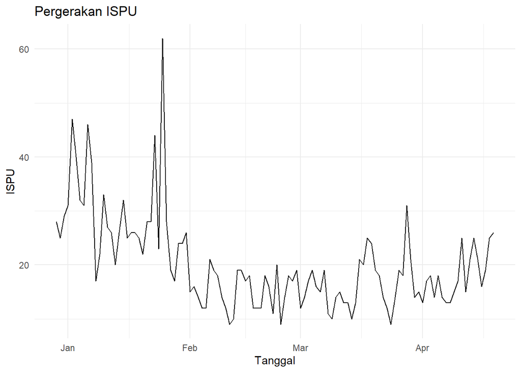

```r
ggplot(data, aes(x = tanggal, y = max)) +
  geom_line() +
  labs(title = "Pergerakan ISPU",
       x = "Tanggal",
       y = "ISPU") +
  theme_minimal()
```

Berdasarkan grafik, nilai ISPU mengalami fluktuasi yang cukup tinggi dari Januari hingga April. Pada awal Januari, ISPU berada di kisaran 20–30 dan beberapa kali meningkat hingga sekitar 40–45. Nilai tertinggi terjadi pada akhir Januari dengan ISPU mencapai sekitar 60, kemudian mengalami penurunan cukup signifikan pada awal Februari. Selanjutnya, selama Februari hingga Maret, nilai ISPU cenderung lebih rendah dan berfluktuasi di kisaran 10–20. Memasuki April, nilai ISPU kembali mengalami peningkatan dan berada pada kisaran 15–30. Secara umum, kualitas udara pada periode tersebut menunjukkan perubahan yang cukup dinamis dengan beberapa peningkatan ISPU pada waktu tertentu.

# Membentuk data time series

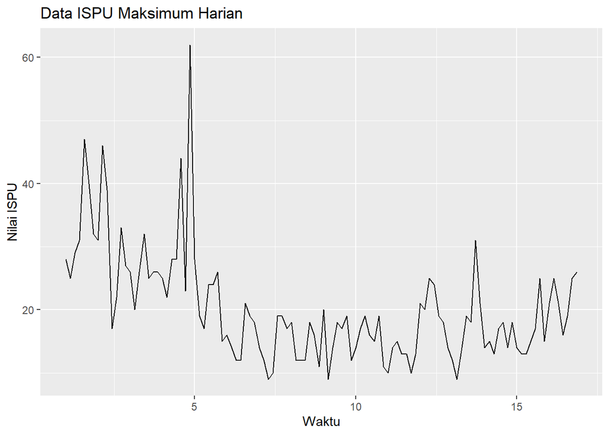

```r
ispu_ts <- ts(data$max, frequency = 7) #(pola mingguan)
autoplot(ispu_ts) +
  ggtitle("Data ISPU Maksimum Harian") +
  xlab("Waktu") +
  ylab("Nilai ISPU")
```

Berdasarkan grafik, nilai ISPU maksimum harian mengalami fluktuasi selama periode pengamatan. Nilai tertinggi mencapai sekitar 62 pada periode ke-5, kemudian menurun dan cenderung berada pada kisaran 10–20, meskipun terdapat beberapa kenaikan pada periode tertentu.

# Membagi data training dan testing

```r
n <- length(ispu_ts)

n_train <- floor(0.8 * n)

train <- window(ispu_ts, end = time(ispu_ts)[n_train])
test <- window(ispu_ts, start = time(ispu_ts)[n_train + 1])

length(train)
```

```
## [1] 89
```

```r
length(test)
```

```
## [1] 23
```

## Plot Training

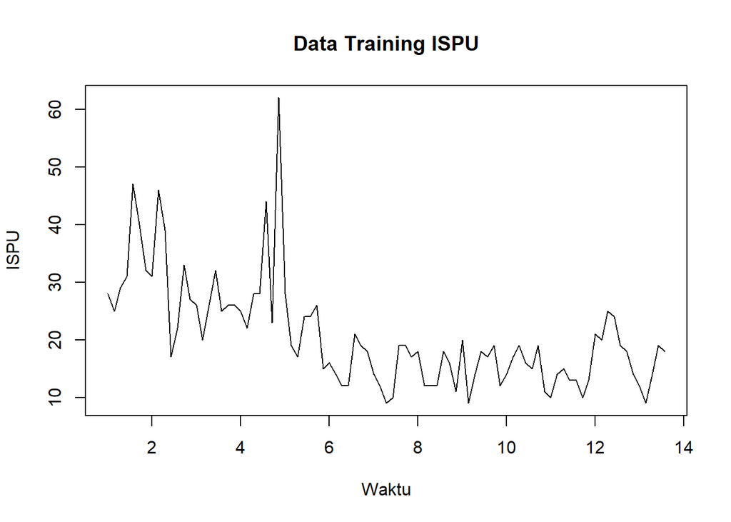

```r
plot(train,
     main = "Data Training ISPU",
     ylab = "ISPU",
     xlab = "Waktu")
```

Berdasarkan grafik Data Training ISPU, nilai ISPU pada data training (89 data) mengalami fluktuasi. Nilai tertinggi mencapai sekitar 62, kemudian cenderung menurun dan berada pada kisaran 10–20 di sebagian besar periode pengamatan. Data training ini mencakup 80% dari keseluruhan data, yaitu sebanyak 89 observasi, sedangkan 23 observasi digunakan sebagai data testing.

# Uji Stasioneritas Data Training

```r
adf_train <- adf.test(train)

adf_train
```

```
##
##  Augmented Dickey-Fuller Test
##
## data:  train
## Dickey-Fuller = -2.841, Lag order = 4, p-value = 0.2301
## alternative hypothesis: stationary
```

Berdasarkan hasil Augmented Dickey-Fuller (ADF) Test, diperoleh nilai p-value sebesar 0,2301. Karena nilai tersebut lebih besar dari 0,05, maka H₀ tidak ditolak, sehingga data training ISPU belum stasioner.

# Differencing Orde 1

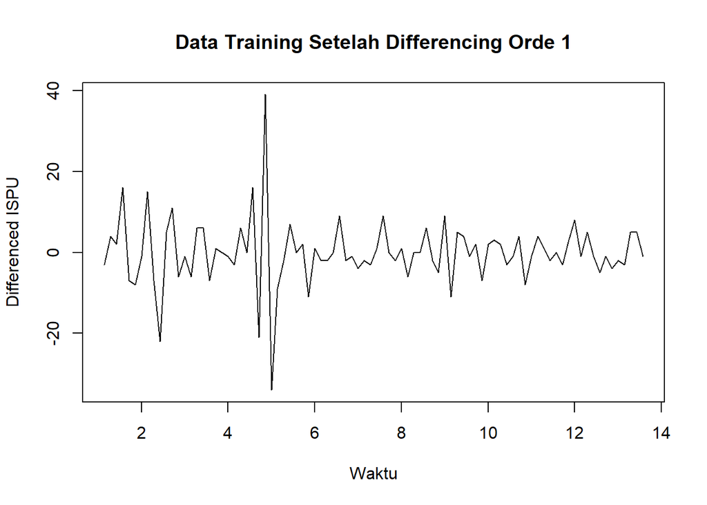

```r
train_diff1 <- diff(train)

# Plot data setelah differencing
plot(train_diff1,
     main = "Data Training Setelah Differencing Orde 1",
     xlab = "Waktu",
     ylab = "Differenced ISPU")
```

# Uji ADF setelah differencing

```r
adf_diff1 <- adf.test(train_diff1)
adf_diff1
```

```
##
##  Augmented Dickey-Fuller Test
##
## data:  train_diff1
## Dickey-Fuller = -6.0576, Lag order = 4, p-value = 0.01
## alternative hypothesis: stationary
```

Berdasarkan uji Augmented Dickey-Fuller (ADF), data training setelah dilakukan differencing orde 1 memiliki p-value sebesar 0,01. Karena p-value < 0,05, maka H₀ ditolak. Artinya, data setelah differencing orde 1 sudah stasioner. Oleh karena itu, proses differencing dilakukan sebanyak satu kali sehingga diperoleh d = 1 pada model ARIMA.

# ACF dan PACF

[figure not shown]

```r
# Plot ACF dan PACF
par(mfrow = c(1, 2))

acf(train, main = "Plot ACF Differencing Orde 1")
pacf(train, main = "Plot PACF Differencing Orde 1")
```

```r
par(mfrow = c(1, 1))
```

Berdasarkan grafik ACF, terlihat bahwa nilai autokorelasi menurun secara bertahap dan masih terdapat beberapa lag yang melewati batas signifikansi. Hal ini menunjukkan bahwa data masih memiliki korelasi antarwaktu. Sementara itu, pada grafik PACF, terdapat spike yang signifikan terutama pada lag awal, sehingga dapat menjadi pertimbangan dalam menentukan orde model ARIMA.

# Pemilihan Model dengan Auto.ARIMA

```r
model_auto <- auto.arima(
  train,
  d = 1,
  seasonal = FALSE,
  stepwise = FALSE,
  approximation = FALSE
)
summary(model_auto)
```

```
## Series: train
## ARIMA(0,1,1)
##
## Coefficients:
##           ma1
##       -0.7110
## s.e.   0.1031
##
## sigma^2 = 51.12:  log likelihood = -297.82
## AIC=599.64   AICc=599.78   BIC=604.6
##
## Training set error measures:
##                      ME     RMSE     MAE       MPE     MAPE      MASE
## Training set -0.4667814 7.069115 4.92864 -10.04687 25.78238 0.7348155
##                    ACF1
## Training set 0.08652755
```

```r
model_auto
```

```
## Series: train
## ARIMA(0,1,1)
##
## Coefficients:
##           ma1
##       -0.7110
## s.e.   0.1031
##
## sigma^2 = 51.12:  log likelihood = -297.82
## AIC=599.64   AICc=599.78   BIC=604.6
```

Berdasarkan hasil pemodelan ARIMA(0,1,1) pada data training, diperoleh koefisien MA(1) sebesar -0,7110 dengan nilai RMSE sebesar 7,0691 dan MAE sebesar 4,9286. Nilai MAPE sebesar 25,7824% menunjukkan rata-rata kesalahan prediksi sekitar 25,78%. Model ini juga menghasilkan nilai AIC sebesar 599,64 dan BIC sebesar 604,60, yang dapat digunakan untuk membandingkan model ARIMA dengan model lainnya.

# Membandingkan Beberapa Model ARIMA

```r
model_110 <- Arima(train,
                   order = c(1,1,0))

model_011 <- Arima(train,
                   order = c(0,1,1))

model_111 <- Arima(train,
                   order = c(1,1,1))

model_210 <- Arima(train,
                   order = c(2,1,0))

model_012 <- Arima(train,
                   order = c(0,1,2))
```

# Perbandungan AIC dan BIC

```r
daftar_model <- list(
  "ARIMA(1,1,0)" = model_110,
  "ARIMA(0,1,1)" = model_011,
  "ARIMA(1,1,1)" = model_111,
  "ARIMA(2,1,0)" = model_210,
  "ARIMA(0,1,2)" = model_012,
  "Auto ARIMA" = model_auto
)

perbandingan_model <- data.frame(
  Model = names(daftar_model),
  AIC = sapply(daftar_model, AIC),
  BIC = sapply(daftar_model, BIC)
)

# Mengurutkan berdasarkan AIC terkecil
perbandingan_model <- perbandingan_model[
  order(perbandingan_model$AIC), ]

perbandingan_model
```

```
##                     Model      AIC      BIC
## ARIMA(0,1,1) ARIMA(0,1,1) 599.6413 604.5959
## Auto ARIMA     Auto ARIMA 599.6413 604.5959
## ARIMA(1,1,1) ARIMA(1,1,1) 599.6988 607.1308
## ARIMA(0,1,2) ARIMA(0,1,2) 600.1434 607.5754
## ARIMA(2,1,0) ARIMA(2,1,0) 609.3941 616.8261
## ARIMA(1,1,0) ARIMA(1,1,0) 610.3645 615.3192
```

Berdasarkan tabel perbandingan, ARIMA(0,1,1) dan Auto ARIMA memiliki nilai AIC dan BIC yang sama, yaitu AIC 599,6413 dan BIC 604,5959. Model ARIMA(1,1,1) memiliki nilai yang sedikit lebih besar, sedangkan model lainnya memiliki AIC dan BIC yang lebih tinggi. Perbandingan ini menunjukkan bahwa model dengan nilai AIC dan BIC yang lebih kecil memiliki kecocokan model yang lebih baik terhadap data.

# Model Final Sementara

```r
nama_model_terpilih <- perbandingan_model$Model[1]

model_final <- daftar_model[[nama_model_terpilih]]

cat("Kandidat model berdasarkan AIC:",
    nama_model_terpilih, "\n")
```

```
## Kandidat model berdasarkan AIC: ARIMA(0,1,1)
```

```r
summary(model_final)
```

```
## Series: train
## ARIMA(0,1,1)
##
## Coefficients:
##           ma1
##       -0.7110
## s.e.   0.1031
##
## sigma^2 = 51.12:  log likelihood = -297.82
## AIC=599.64   AICc=599.78   BIC=604.6
##
## Training set error measures:
##                      ME     RMSE     MAE       MPE     MAPE      MASE
## Training set -0.4667814 7.069115 4.92864 -10.04687 25.78238 0.7348155
##                    ACF1
## Training set 0.08652755
```

```r
# Melihat orde ARIMA model
arimaorder(model_final)
```

```
## p d q
## 0 1 1
```

# Diagnostik Residual

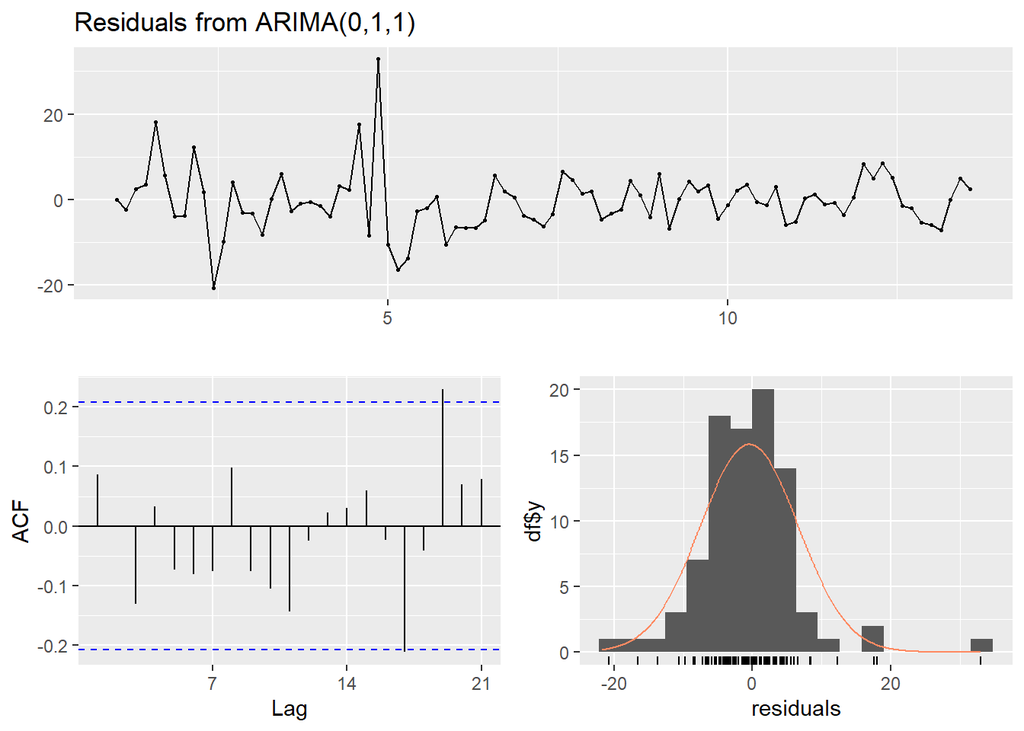

```
##
##  Ljung-Box test
##
## data:  Residuals from ARIMA(0,1,1)
## Q* = 9.2062, df = 13, p-value = 0.7572
##
## Model df: 1.   Total lags used: 14
```

```r
checkresiduals(model_final)
```

Berdasarkan grafik residual ARIMA(0,1,1), residual terlihat berfluktuasi di sekitar nilai nol. Pada grafik ACF, sebagian besar nilai autokorelasi berada di dalam batas signifikansi, sehingga residual dapat dianggap tidak memiliki autokorelasi yang signifikan. Histogram residual juga menunjukkan pola yang relatif mendekati distribusi normal.

# Uji Ljung-Box

```r
orde <- arimaorder(model_final)

uji_ljung_box <- Box.test(
  residuals(model_final),
  lag = 10,
  type = "Ljung-Box",
  fitdf = orde["p"] + orde["q"]
)

print(uji_ljung_box)
```

```
##
##  Box-Ljung test
##
## data:  residuals(model_final)
## X-squared = 6.8434, df.p = 9, p-value = 0.6534
```

Berdasarkan hasil uji Ljung-Box, diperoleh nilai statistik $X^2$ = 6,834, derajat bebas sebesar 9, dan p-value sebesar 0,6534. Karena p-value lebih besar dari taraf signifikansi 0,05, maka H₀ gagal ditolak. Hal ini menunjukkan bahwa tidak terdapat autokorelasi yang signifikan pada residual model ARIMA, sehingga residual dapat dianggap memenuhi karakteristik white noise. Dengan demikian, model telah memenuhi kriteria diagnostik residual dari sisi autokorelasi dan dapat dilanjutkan ke tahap evaluasi akurasi peramalan.

# Forecast Pada Data Testing

```r
h <- length(test)

forecast_test <- forecast(
  model_final,
  h = h
)

forecast_test
```

```
##          Point Forecast     Lo 80    Hi 80       Lo 95    Hi 95
## 13.71429       16.21722 7.0542414 25.38019  2.20365569 30.23078
## 13.85714       16.21722 6.6793396 25.75509  1.63029281 30.80414
## 14.00000       16.21722 6.3186267 26.11581  1.07863007 31.35580
## 14.14286       16.21722 5.9706042 26.46383  0.54637557 31.88806
## 14.28571       16.21722 5.6340200 26.80041  0.03161452 32.40282
## 14.42857       16.21722 5.3078154 27.12662 -0.46727234 32.90170
## 14.57143       16.21722 4.9910856 27.44335 -0.95166885 33.38610
## 14.71429       16.21722 4.6830499 27.75138 -1.42276877 33.85720
## 14.85714       16.21722 4.3830295 28.05140 -1.88161044 34.31604
## 15.00000       16.21722 4.0904294 28.34400 -2.32910369 34.76354
## 15.14286       16.21722 3.8047248 28.62971 -2.76605110 35.20048
## 15.28571       16.21722 3.5254501 28.90898 -3.19316487 35.62760
## 15.42857       16.21722 3.2521898 29.18224 -3.61108048 36.04551
## 15.57143       16.21722 2.9845712 29.44986 -4.02036777 36.45480
## 15.71429       16.21722 2.7222587 29.71217 -4.42154008 36.85597
## 15.85714       16.21722 2.4649487 29.96948 -4.81506177 37.24949
## 16.00000       16.21722 2.2123655 30.22207 -5.20135454 37.63579
## 16.14286       16.21722 1.9642576 30.47017 -5.58080271 38.01523
## 16.28571       16.21722 1.7203955 30.71404 -5.95375772 38.38819
## 16.42857       16.21722 1.4805682 30.95386 -6.32054190 38.75497
## 16.57143       16.21722 1.2445819 31.18985 -6.68145180 39.11588
## 16.71429       16.21722 1.0122577 31.42217 -7.03676092 39.47119
## 16.85714       16.21722 0.7834304 31.65100 -7.38672220 39.82115
```

Berdasarkan hasil forecasting pada data testing, model ARIMA(0,1,1) menghasilkan nilai ramalan (point forecast) sebesar 16,2172 untuk seluruh periode pengujian. Interval prediksi 80% dan 95% juga menunjukkan rentang nilai ramalan yang semakin lebar pada periode berikutnya. Hal ini menunjukkan bahwa ketidakpastian hasil prediksi meningkat seiring bertambahnya periode yang diramalkan.

# Plot Forecast VS Data Aktual

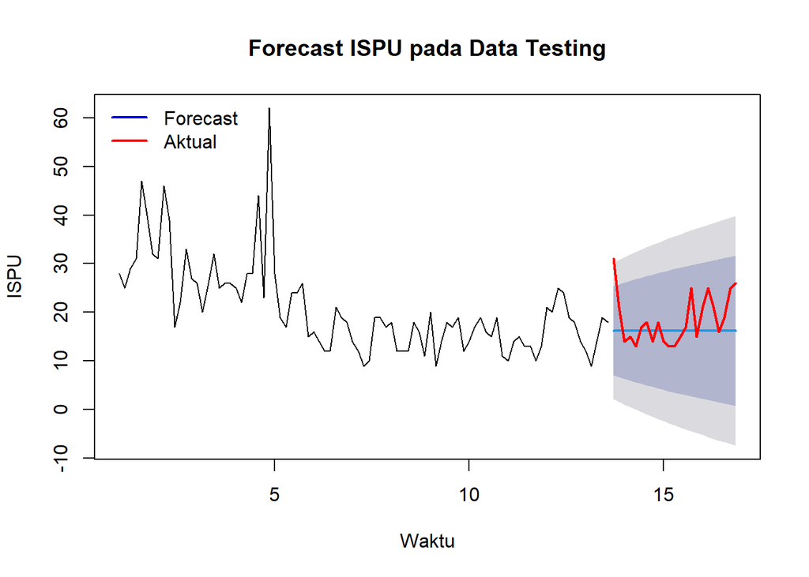

```r
plot(forecast_test,
     main = "Forecast ISPU pada Data Testing",
     xlab = "Waktu",
     ylab = "ISPU")

lines(test,
      col = "red",
      lwd = 2)

legend("topleft",
       legend = c("Forecast", "Aktual"),
       col = c("blue", "red"),
       lty = 1,
       lwd = 2,
       bty = "n")
```

Berdasarkan grafik, hasil forecasting ISPU pada data testing menunjukkan bahwa nilai ramalan (garis biru) relatif stabil di sekitar 16,22. Sementara itu, nilai aktual (garis merah) mengalami fluktuasi, dengan beberapa nilai berada di atas maupun di bawah hasil ramalan. Secara umum, interval prediksi mencakup sebagian besar nilai aktual, meskipun rentang interval semakin melebar pada periode berikutnya.

# Mengukur akurasi forecast

```r
akurasi <- accuracy(forecast_test, test)

(akurasi)
```

```
##                      ME     RMSE      MAE        MPE     MAPE      MASE
## Training set -0.4667814 7.069115 4.928640 -10.046872 25.78238 0.7348155
## Test set      2.3045232 5.436943 4.058624   6.749497 19.57186 0.6051039
##                    ACF1 Theil's U
## Training set 0.08652755        NA
## Test set     0.33424845 0.9606986
```

```r
akurasi_testing <- akurasi[
  "Test set",
  c("RMSE", "MAE", "MAPE")
]

akurasi_testing
```

```
##      RMSE       MAE      MAPE
##  5.436943  4.058624 19.571856
```

Berdasarkan hasil pengukuran akurasi, pada data testing diperoleh nilai RMSE sebesar 5,44, MAE sebesar 4,06, dan MAPE sebesar 19,57%. Nilai tersebut menunjukkan bahwa model ARIMA(0,1,1) menghasilkan kesalahan prediksi rata-rata sekitar 19,57% pada data testing.

# Refit Model Menggunakan seluruh data

```r
# Model final adalah ARIMA(0,1,1)
model_semua_data <- Arima(
  ispu_ts,
  order = c(0, 1, 1)
)

summary(model_semua_data)
```

```
## Series: ispu_ts
## ARIMA(0,1,1)
##
## Coefficients:
##           ma1
##       -0.7144
## s.e.   0.0939
##
## sigma^2 = 45.73:  log likelihood = -369.52
## AIC=743.04   AICc=743.16   BIC=748.46
##
## Training set error measures:
##                      ME    RMSE      MAE       MPE   MAPE      MASE      ACF1
## Training set -0.1863428 6.70189 4.698566 -8.138794 24.574 0.7463683 0.1056444
```

Berdasarkan hasil refitting model menggunakan seluruh data, model yang digunakan tetap ARIMA(0,1,1). Setelah model diterapkan pada seluruh data, diperoleh nilai RMSE sebesar 6,70 dan MAE sebesar 4,70, dengan MAPE sebesar 24,57%. Koefisien MA(1) yang dihasilkan sebesar -0,7144.

# Forecasting 30 Periode

```r
forecast_30 <- forecast(
  model_semua_data,
  h = 30,
  level = 95
)

print(forecast_30)
```

```
##          Point Forecast      Lo 95    Hi 95
## 17.00000       22.28347  9.0291287 35.53781
## 17.14286       22.28347  8.4990493 36.06789
## 17.28571       22.28347  7.9886127 36.57832
## 17.42857       22.28347  7.4957847 37.07115
## 17.57143       22.28347  7.0188597 37.54808
## 17.71429       22.28347  6.5563908 38.01055
## 17.85714       22.28347  6.1071382 38.45980
## 18.00000       22.28347  5.6700296 38.89691
## 18.14286       22.28347  5.2441304 39.32281
## 18.28571       22.28347  4.8286201 39.73832
## 18.42857       22.28347  4.4227736 40.14416
## 18.57143       22.28347  4.0259465 40.54099
## 18.71429       22.28347  3.6375628 40.92937
## 18.85714       22.28347  3.2571055 41.30983
## 19.00000       22.28347  2.8841082 41.68283
## 19.14286       22.28347  2.5181487 42.04879
## 19.28571       22.28347  2.1588428 42.40809
## 19.42857       22.28347  1.8058405 42.76110
## 19.57143       22.28347  1.4588211 43.10811
## 19.71429       22.28347  1.1174905 43.44945
## 19.85714       22.28347  0.7815775 43.78536
## 20.00000       22.28347  0.4508322 44.11610
## 20.14286       22.28347  0.1250233 44.44191
## 20.28571       22.28347 -0.1960641 44.76300
## 20.42857       22.28347 -0.5126293 45.07957
## 20.57143       22.28347 -0.8248582 45.39179
## 20.71429       22.28347 -1.1329243 45.69986
## 20.85714       22.28347 -1.4369898 46.00393
## 21.00000       22.28347 -1.7372066 46.30414
## 21.14286       22.28347 -2.0337172 46.60065
```

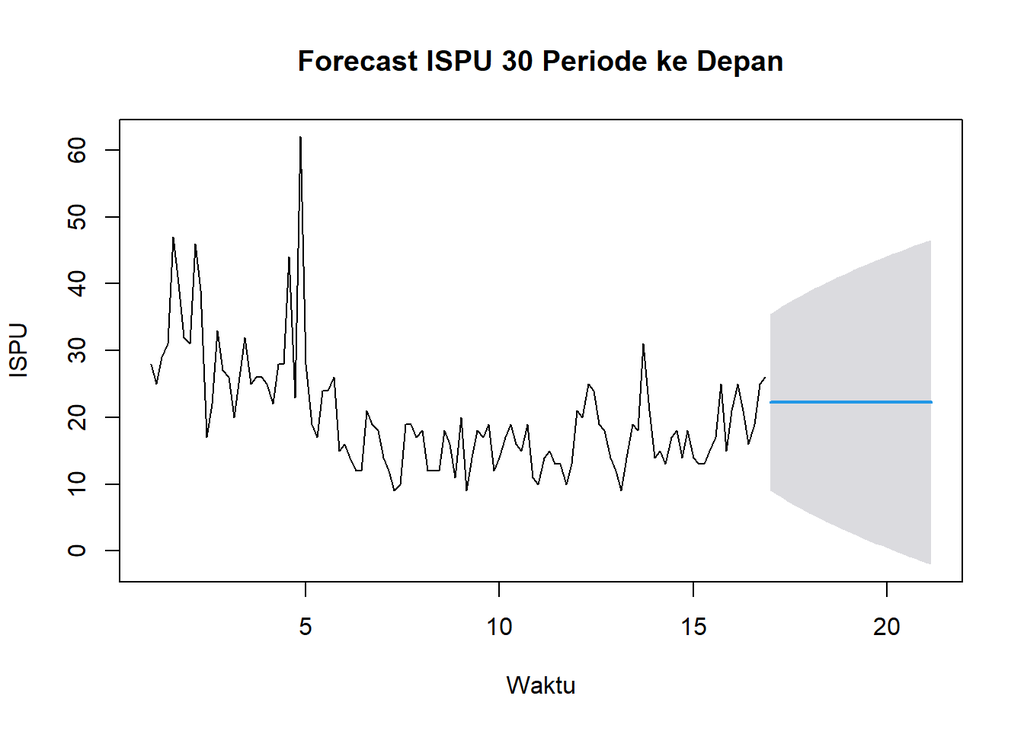

```r
plot(forecast_30,
     main = "Forecast ISPU 30 Periode ke Depan",
     xlab = "Waktu",
     ylab = "ISPU")
```

Berdasarkan grafik forecast ISPU 30 periode ke depan, hasil peramalan menunjukkan nilai ISPU diperkirakan stabil di sekitar 22 pada seluruh periode mendatang. Sementara itu, interval prediksi semakin melebar seiring bertambahnya periode, yang menunjukkan bahwa ketidakpastian hasil peramalan semakin besar untuk periode yang lebih jauh.

```r
hasil_forecast <- data.frame(
  Periode = 1:30,
  Tanggal = seq(
    from = max(data$tanggal) + 1,
    by = "day",
    length.out = 30
  ),
  Forecast = as.numeric(forecast_30$mean),
  Lower_95 = as.numeric(forecast_30$lower[, "95%"]),
  Upper_95 = as.numeric(forecast_30$upper[, "95%"])
)

hasil_forecast
```

```
##    Periode    Tanggal Forecast   Lower_95 Upper_95
## 1        1 2021-04-20 22.28347  9.0291287 35.53781
## 2        2 2021-04-21 22.28347  8.4990493 36.06789
## 3        3 2021-04-22 22.28347  7.9886127 36.57832
## 4        4 2021-04-23 22.28347  7.4957847 37.07115
## 5        5 2021-04-24 22.28347  7.0188597 37.54808
## 6        6 2021-04-25 22.28347  6.5563908 38.01055
## 7        7 2021-04-26 22.28347  6.1071382 38.45980
## 8        8 2021-04-27 22.28347  5.6700296 38.89691
## 9        9 2021-04-28 22.28347  5.2441304 39.32281
## 10      10 2021-04-29 22.28347  4.8286201 39.73832
## 11      11 2021-04-30 22.28347  4.4227736 40.14416
## 12      12 2021-05-01 22.28347  4.0259465 40.54099
## 13      13 2021-05-02 22.28347  3.6375628 40.92937
## 14      14 2021-05-03 22.28347  3.2571055 41.30983
```

[output cut: 16 more lines]

Hasil peramalan 30 periode ke depan menunjukkan bahwa nilai ISPU diprediksi konstan sebesar 22,28. Interval prediksi 95% semakin lebar seiring bertambahnya periode, yaitu dari 9,03–35,54 pada periode pertama hingga semakin luas pada periode berikutnya. Hal ini menunjukkan adanya ketidakpastian yang semakin besar dalam hasil peramalan jangka panjang.

#Kesimpulan Berdasarkan hasil analisis, data ISPU menunjukkan pola yang cenderung fluktuatif dan belum stasioner sehingga dilakukan differencing orde 1. Berdasarkan perbandingan beberapa model, diperoleh ARIMA(0,1,1) sebagai model dengan nilai AIC terendah. Hasil pengujian residual menunjukkan bahwa model sudah cukup baik dalam menangkap pola data. Pada data testing, model menghasilkan RMSE sebesar 5,44, MAE sebesar 4,06, dan MAPE sebesar 19,57%, sehingga hasil peramalan memiliki tingkat kesalahan rata-rata sekitar 19,57%. Selanjutnya, peramalan 30 periode ke depan menghasilkan nilai ISPU sekitar 22,28, dengan interval prediksi yang semakin lebar seiring bertambahnya periode.